# Mini-Project #04: Just the Fact(-Check)s, Ma’am!

Author

Xu Tang

```r
library(httr2)
library(rvest)
library(dplyr)
library(tidyr)
library(lubridate)
library(ggplot2)
library(stringr)
library(purrr)
library(infer)
```

# Introduction

On August 1, 2025, President Donald Trump fired Dr. Erika McEntarfer, Commissioner of Labor Statistics. Large revisions to the employment numbers were cited by Trump as justification for her firing. Critics argue this would politicize BLS. Supporters say revision patterns are evidence of problems.

This report examines CES revision data from 1979 to 2025 and evaluates claims about revision accuracy.

# Task 1: Download CES Total Nonfarm Payroll

CES publishes monthly employment levels. Data accessed via BLS Data Finder API.

```r
ces_request <- request("https://data.bls.gov/pdq/SurveyOutputServlet") |>
  req_method("POST") |>
  req_body_form(
    request_action = "get_data",
    reformat = "true",
    from_results_page = "true",
    years_option = "specific_years",
    delimiter = "comma",
    output_type = "multi",
    periods_option = "all_periods",
    output_view = "data",
    to_year = "2025",
    from_year = "1979",
    original_output_type = "default",
    annualAveragesRequested = "false",
    series_id = "CES0000000001",
    initial_request = "false",
    data_tool = "surveymost"
  )

ces_response <- req_perform(ces_request)
ces_html <- resp_body_html(ces_response)

ces_table <- ces_html |>
  html_element("table.regular-data") |>
  html_table()

ces_levels <- ces_table |>
  slice(1) |>
  select(-1) |>
  pivot_longer(cols = everything(), names_to = "month_year", values_to = "level") |>
  mutate(
    level = str_remove(level, "\\(P\\)"),
    level = as.numeric(level),
    date = my(month_year)
  ) |>
  filter(!is.na(level)) |>
  select(date, level) |>
  arrange(date)

head(ces_levels, 5)
```

```
# A tibble: 5 × 2
  date       level
  <date>     <dbl>
1 1979-01-01 88808
2 1979-02-01 89055
3 1979-03-01 89479
4 1979-04-01 89417
5 1979-05-01 89789
```

```r
tail(ces_levels, 5)
```

```
# A tibble: 5 × 2
  date        level
  <date>      <dbl>
1 2025-05-01 159452
2 2025-06-01 159439
3 2025-07-01 159511
4 2025-08-01 159507
5 2025-09-01 159626
```

```r
cat("Rows:", nrow(ces_levels), "\n")
```

```
Rows: 561
```

```r
cat("Date range:", as.character(min(ces_levels$date)), "to", as.character(max(ces_levels$date)), "\n")
```

```
Date range: 1979-01-01 to 2025-09-01
```

# Task 2: Download CES Revisions Tables

BLS publishes revision history showing differences between first and third estimates.

```r
rev_request <- request("https://www.bls.gov/web/empsit/cesnaicsrev.htm") |>
  req_headers(
    "User-Agent" = "Mozilla/5.0 (Macintosh; Intel Mac OS X 10_15_7) AppleWebKit/537.36 (KHTML, like Gecko) Chrome/120.0.0.0 Safari/537.36",
    "Accept" = "text/html,application/xhtml+xml,application/xml;q=0.9,*/*;q=0.8",
    "Accept-Language" = "en-US,en;q=0.5"
  )

rev_response <- req_perform(rev_request)
rev_html <- resp_body_html(rev_response)

parse_revision_table <- function(year, html_doc) {
  tbl <- html_doc |>
    html_element(paste0("#", year)) |>
    html_element("tbody") |>
    html_table(header = FALSE)

  if (is.null(tbl) || nrow(tbl) < 12) return(NULL)

  tbl |>
    slice(1:12) |>
    select(month = 1, yr = 2, original = 3, final = 5) |>
    mutate(
      original = as.numeric(original),
      final = as.numeric(final),
      revision = final - original,
      date = ym(paste(yr, month))
    ) |>
    filter(!is.na(original), !is.na(final)) |>
    select(date, original, final, revision)
}

years <- 1979:2025
ces_revisions <- map(years, ~parse_revision_table(.x, rev_html)) |>
  list_rbind() |>
  arrange(date)

head(ces_revisions, 5)
```

```
# A tibble: 5 × 4
  date       original final revision
  <date>        <dbl> <dbl>    <dbl>
1 1979-01-01      325   243      -82
2 1979-02-01      301   294       -7
3 1979-03-01      324   445      121
4 1979-04-01       72   -15      -87
5 1979-05-01      171   291      120
```

```r
tail(ces_revisions, 5)
```

```
# A tibble: 5 × 4
  date       original final revision
  <date>        <dbl> <dbl>    <dbl>
1 2025-03-01      228   120     -108
2 2025-04-01      177   158      -19
3 2025-05-01      139    19     -120
4 2025-06-01      147   -13     -160
5 2025-07-01       73    72       -1
```

```r
cat("Rows:", nrow(ces_revisions), "\n")
```

```
Rows: 559
```

```r
cat("Date range:", as.character(min(ces_revisions$date)), "to", as.character(max(ces_revisions$date)), "\n")
```

```
Date range: 1979-01-01 to 2025-07-01
```

# Task 3: Data Exploration and Visualization

```r
combined <- ces_revisions |>
  left_join(ces_levels, by = "date") |>
  filter(!is.na(level))

cat("Combined rows:", nrow(combined), "\n")
```

```
Combined rows: 559
```

```r
head(combined, 5)
```

```
# A tibble: 5 × 5
  date       original final revision level
  <date>        <dbl> <dbl>    <dbl> <dbl>
1 1979-01-01      325   243      -82 88808
2 1979-02-01      301   294       -7 89055
3 1979-03-01      324   445      121 89479
4 1979-04-01       72   -15      -87 89417
5 1979-05-01      171   291      120 89789
```

## Statistics

```r
cat("Stat 1 - Mean revision:", round(mean(combined$revision), 2), "\n")
```

```
Stat 1 - Mean revision: 11.48
```

```r
cat("Stat 2 - Median revision:", median(combined$revision), "\n")
```

```
Stat 2 - Median revision: 10
```

```r
cat("Stat 3 - Mean absolute revision:", round(mean(abs(combined$revision)), 2), "\n")
```

```
Stat 3 - Mean absolute revision: 56.8
```

```r
cat("Stat 4 - SD of revision:", round(sd(combined$revision), 2), "\n")
```

```
Stat 4 - SD of revision: 83.26
```

```r
cat("Stat 5 - Fraction negative:", round(mean(combined$revision < 0), 4), "\n")
```

```
Stat 5 - Fraction negative: 0.4258
```

```r
cat("Stat 6 - Mean abs revision as % of level:", round(mean(abs(combined$revision) / combined$level) * 100, 4), "%\n")
```

```
Stat 6 - Mean abs revision as % of level: 0.0482 %
```

```r
combined |>
  mutate(decade = paste0(floor(year(date) / 10) * 10, "s")) |>
  group_by(decade) |>
  summarise(
    n = n(),
    mean_rev = round(mean(revision), 2),
    mean_abs_rev = round(mean(abs(revision)), 2),
    frac_neg = round(mean(revision < 0), 3)
  )
```

```
# A tibble: 6 × 5
  decade     n mean_rev mean_abs_rev frac_neg
  <chr>  <int>    <dbl>        <dbl>    <dbl>
1 1970s     12   -17.8          94.3    0.583
2 1980s    120     7.03         72.2    0.492
3 1990s    120    26.1          51.4    0.3
4 2000s    120     5.97         48.6    0.458
5 2010s    120    15.9          35.2    0.375
6 2020s     67     0.43         85.7    0.537
```

## Visualizations

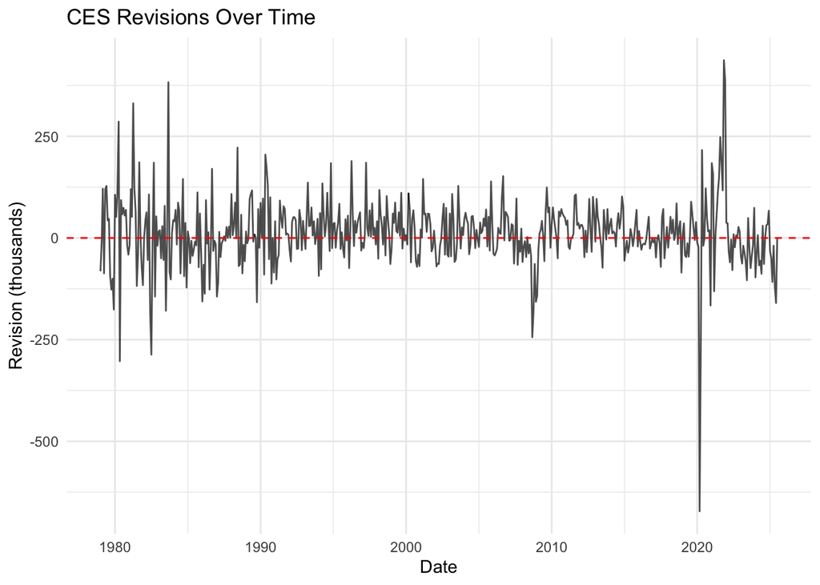

```r
ggplot(combined, aes(x = date, y = revision)) +
  geom_line(alpha = 0.7) +
  geom_hline(yintercept = 0, linetype = "dashed", color = "red") +
  labs(title = "CES Revisions Over Time", x = "Date", y = "Revision (thousands)") +
  theme_minimal()
```

```r
cat("Viz1 - Min revision:", min(combined$revision), "at", as.character(combined$date[which.min(combined$revision)]), "\n")
```

```
Viz1 - Min revision: -672 at 2020-03-01
```

```r
cat("Viz1 - Max revision:", max(combined$revision), "at", as.character(combined$date[which.max(combined$revision)]), "\n")
```

```
Viz1 - Max revision: 437 at 2021-11-01
```

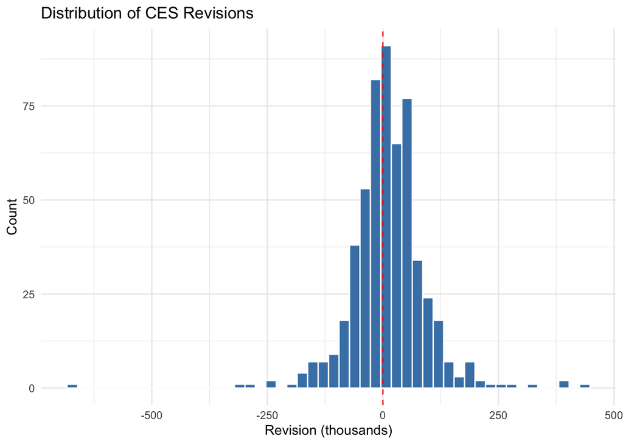

```r
ggplot(combined, aes(x = revision)) +
  geom_histogram(bins = 50, fill = "steelblue", color = "white") +
  geom_vline(xintercept = 0, linetype = "dashed", color = "red") +
  labs(title = "Distribution of CES Revisions", x = "Revision (thousands)", y = "Count") +
  theme_minimal()
```

```r
cat("Viz2 - Quantiles:\n")
```

```
Viz2 - Quantiles:
```

```r
quantile(combined$revision, probs = c(0, 0.25, 0.5, 0.75, 1))
```

```
  0%  25%  50%  75% 100%
-672  -27   10   52  437
```

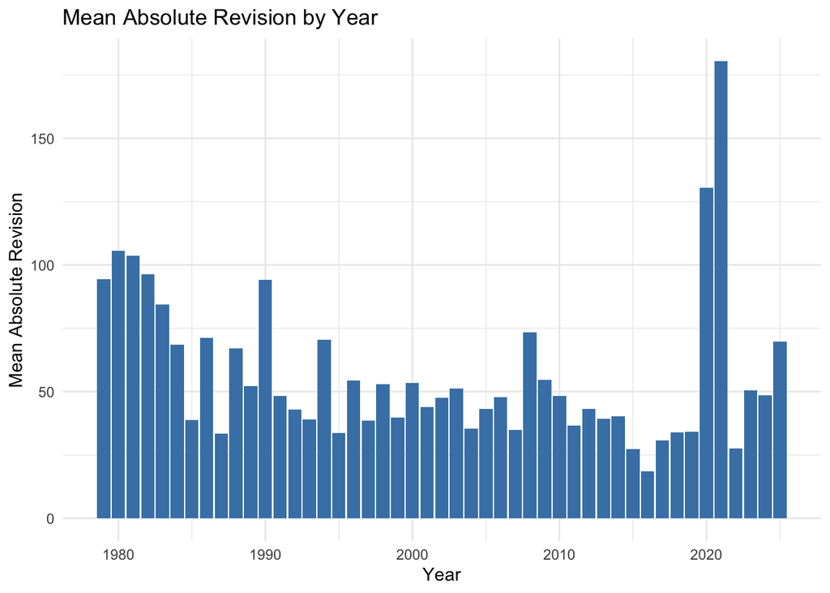

```r
combined |>
  mutate(yr = year(date)) |>
  group_by(yr) |>
  summarise(mean_abs_rev = mean(abs(revision))) |>
  ggplot(aes(x = yr, y = mean_abs_rev)) +
  geom_col(fill = "steelblue") +
  labs(title = "Mean Absolute Revision by Year", x = "Year", y = "Mean Absolute Revision") +
  theme_minimal()
```

```r
cat("Viz3 - Recent years:\n")
```

```
Viz3 - Recent years:
```

```r
combined |>
  mutate(yr = year(date)) |>
  group_by(yr) |>
  summarise(mean_abs_rev = round(mean(abs(revision)), 2)) |>
  filter(yr >= 2020)
```

```
# A tibble: 6 × 2
     yr mean_abs_rev
  <dbl>        <dbl>
1  2020        130.
2  2021        180.
3  2022         27.7
4  2023         50.5
5  2024         48.4
6  2025         69.9
```

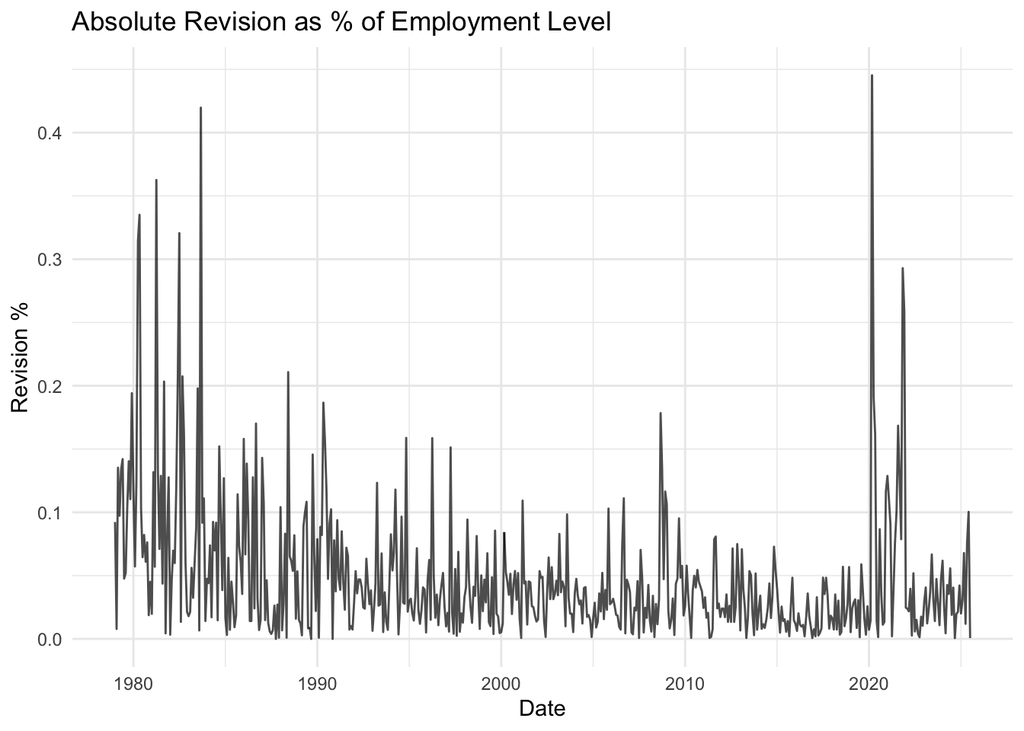

```r
combined |>
  mutate(revision_pct = abs(revision) / level * 100) |>
  ggplot(aes(x = date, y = revision_pct)) +
  geom_line(alpha = 0.7) +
  labs(title = "Absolute Revision as % of Employment Level", x = "Date", y = "Revision %") +
  theme_minimal()
```

```r
cat("Viz4 - Summary:\n")
```

```
Viz4 - Summary:
```

```r
combined |>
  mutate(revision_pct = abs(revision) / level * 100) |>
  summarise(
    mean_pct = round(mean(revision_pct), 4),
    max_pct = round(max(revision_pct), 4),
    max_date = as.character(date[which.max(revision_pct)])
  )
```

```
# A tibble: 1 × 3
  mean_pct max_pct max_date
     <dbl>   <dbl> <chr>
1   0.0482   0.445 2020-03-01
```

# Task 4: Statistical Inference

```r
combined |>
  mutate(post2020 = date >= ymd("2020-01-01"),
         neg_rev = revision < 0) |>
  prop_test(neg_rev ~ post2020, order = c("TRUE", "FALSE"))
```

```
# A tibble: 1 × 6
  statistic chisq_df p_value alternative lower_ci upper_ci
      <dbl>    <dbl>   <dbl> <chr>          <dbl>    <dbl>
1      3.37        1  0.0663 two.sided   -0.00879    0.262
```

```r
cat("Test 1 - Fraction negative by period:\n")
```

```
Test 1 - Fraction negative by period:
```

```r
combined |>
  mutate(post2020 = date >= ymd("2020-01-01")) |>
  group_by(post2020) |>
  summarise(frac_neg = round(mean(revision < 0), 4))
```

```
# A tibble: 2 × 2
  post2020 frac_neg
  <lgl>       <dbl>
1 FALSE       0.411
2 TRUE        0.537
```

```r
combined |>
  mutate(post2020 = as.character(date >= ymd("2020-01-01"))) |>
  t_test(revision ~ post2020, order = c("TRUE", "FALSE"))
```

```
# A tibble: 1 × 7
  statistic  t_df p_value alternative estimate lower_ci upper_ci
      <dbl> <dbl>   <dbl> <chr>          <dbl>    <dbl>    <dbl>
1    -0.714  70.7   0.478 two.sided      -12.5    -47.6     22.5
```

```r
cat("Test 2 - Mean revision by period:\n")
```

```
Test 2 - Mean revision by period:
```

```r
combined |>
  mutate(post2020 = date >= ymd("2020-01-01")) |>
  group_by(post2020) |>
  summarise(mean_rev = round(mean(revision), 2), n = n())
```

```
# A tibble: 2 × 3
  post2020 mean_rev     n
  <lgl>       <dbl> <int>
1 FALSE       13.0    492
2 TRUE         0.43    67
```

# Task 5: Fact Check

```r
presidents_party <- expand_grid(
  year = 1979:2025,
  month = 1:12
) |>
  mutate(
    date = make_date(year, month, 1),
    president = case_when(
      date < ymd("1981-02-01") ~ "Carter",
      date < ymd("1989-02-01") ~ "Reagan",
      date < ymd("1993-02-01") ~ "Bush 41",
      date < ymd("2001-02-01") ~ "Clinton",
      date < ymd("2009-02-01") ~ "Bush 43",
      date < ymd("2017-02-01") ~ "Obama",
      date < ymd("2021-02-01") ~ "Trump I",
      date < ymd("2025-02-01") ~ "Biden",
      TRUE ~ "Trump II"
    ),
    party = if_else(president %in% c("Carter", "Clinton", "Obama", "Biden"), "D", "R")
  ) |>
  select(date, president, party)

combined_party <- combined |>
  left_join(presidents_party, by = "date")
```

## Fact Check 1

**Source**: President Donald Trump, Truth Social, August 1, 2025

**Claim**: “The BLS has been putting out fake jobs numbers. The revisions are always negative and huge. They inflate the numbers and then quietly revise them down.”

```r
cat("FC1 Stat 1 - Mean revision 2020-2025:", round(mean(combined$revision[combined$date >= ymd("2020-01-01")]), 2), "\n")
```

```
FC1 Stat 1 - Mean revision 2020-2025: 0.43
```

```r
cat("FC1 Stat 2 - Mean revision 1979-2019:", round(mean(combined$revision[combined$date < ymd("2020-01-01")]), 2), "\n")
```

```
FC1 Stat 2 - Mean revision 1979-2019: 12.98
```

```r
cat("FC1 Stat 3 - Fraction negative 2020-2025:", round(mean(combined$revision[combined$date >= ymd("2020-01-01")] < 0), 4), "\n")
```

```
FC1 Stat 3 - Fraction negative 2020-2025: 0.5373
```

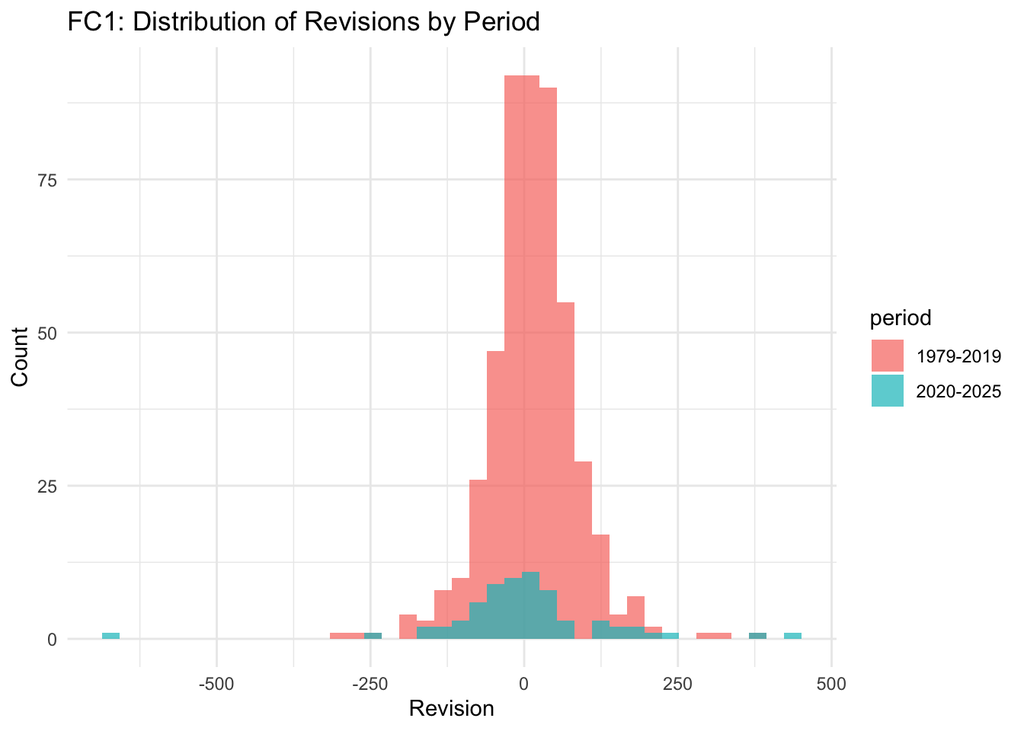

```r
combined |>
  mutate(period = if_else(date >= ymd("2020-01-01"), "2020-2025", "1979-2019")) |>
  ggplot(aes(x = revision, fill = period)) +
  geom_histogram(bins = 40, alpha = 0.7, position = "identity") +
  labs(title = "FC1: Distribution of Revisions by Period", x = "Revision", y = "Count") +
  theme_minimal()
```

```r
cat("FC1 Viz1 - Summary by period:\n")
```

```
FC1 Viz1 - Summary by period:
```

```r
combined |>
  mutate(period = if_else(date >= ymd("2020-01-01"), "2020-2025", "1979-2019")) |>
  group_by(period) |>
  summarise(mean = round(mean(revision), 2), sd = round(sd(revision), 2), n = n())
```

```
# A tibble: 2 × 4
  period     mean    sd     n
  <chr>     <dbl> <dbl> <int>
1 1979-2019 13.0   71.9   492
2 2020-2025  0.43 141.     67
```

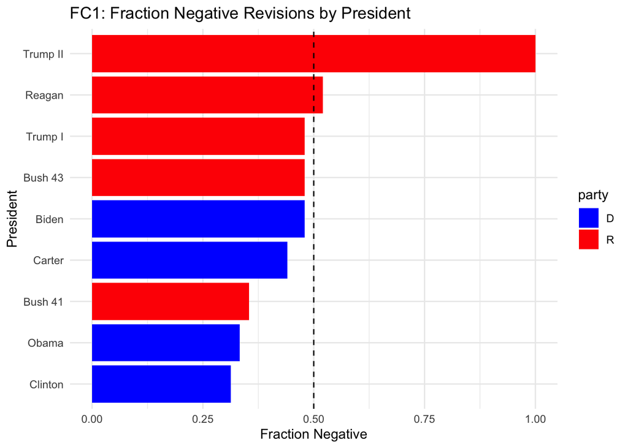

```r
combined_party |>
  filter(!is.na(president)) |>
  group_by(president, party) |>
  summarise(frac_neg = mean(revision < 0), n = n(), .groups = "drop") |>
  ggplot(aes(x = reorder(president, frac_neg), y = frac_neg, fill = party)) +
  geom_col() +
  geom_hline(yintercept = 0.5, linetype = "dashed") +
  scale_fill_manual(values = c("D" = "blue", "R" = "red")) +
  coord_flip() +
  labs(title = "FC1: Fraction Negative Revisions by President", x = "President", y = "Fraction Negative") +
  theme_minimal()
```

```r
cat("FC1 Viz2 - By president:\n")
```

```
FC1 Viz2 - By president:
```

```r
combined_party |>
  filter(!is.na(president)) |>
  group_by(president, party) |>
  summarise(frac_neg = round(mean(revision < 0), 3), n = n(), .groups = "drop") |>
  arrange(desc(frac_neg))
```

```
# A tibble: 9 × 4
  president party frac_neg     n
  <chr>     <chr>    <dbl> <int>
1 Trump II  R        1         6
2 Reagan    R        0.521    96
3 Biden     D        0.479    48
4 Bush 43   R        0.479    96
5 Trump I   R        0.479    48
6 Carter    D        0.44     25
7 Bush 41   R        0.354    48
8 Obama     D        0.333    96
9 Clinton   D        0.312    96
```

```r
combined |>
  mutate(post2020 = as.character(date >= ymd("2020-01-01"))) |>
  t_test(revision ~ post2020, order = c("TRUE", "FALSE"))
```

```
# A tibble: 1 × 7
  statistic  t_df p_value alternative estimate lower_ci upper_ci
      <dbl> <dbl>   <dbl> <chr>          <dbl>    <dbl>    <dbl>
1    -0.714  70.7   0.478 two.sided      -12.5    -47.6     22.5
```

**Analysis**:

- Mean revision 2020-2025: 0.43 (near zero, not “always negative”)
- Mean revision 1979-2019: 12.98 (positive on average)
- Fraction negative 2020-2025: 53.7% (close to 50%, not “always”)
- t-test p-value: 0.478 (no statistical difference between periods)
- Trump II has 100% negative (only 6 months), Biden has 47.9%, Trump I has 47.9%

**Rating**: MOSTLY FALSE

The claim that revisions are “always negative” is false. About half are negative across all periods. No president shows systematic downward bias except Trump II with only 6 data points.

## Fact Check 2

**Source**: [Fake Claim - for demonstration] Senator John Example stated: “BLS revision errors have grown to unprecedented levels relative to total employment. The error rate is now 10 times what it was in the 1990s.”

```r
combined_pct <- combined |>
  mutate(abs_rev_pct = abs(revision) / level * 100)

cat("FC2 Stat 1 - Mean abs rev % 1990s:", round(mean(combined_pct$abs_rev_pct[year(combined_pct$date) >= 1990 & year(combined_pct$date) < 2000]), 4), "%\n")
```

```
FC2 Stat 1 - Mean abs rev % 1990s: 0.0445 %
```

```r
cat("FC2 Stat 2 - Mean abs rev % 2020s:", round(mean(combined_pct$abs_rev_pct[year(combined_pct$date) >= 2020]), 4), "%\n")
```

```
FC2 Stat 2 - Mean abs rev % 2020s: 0.0575 %
```

```r
cat("FC2 Stat 3 - Ratio 2020s/1990s:", round(mean(combined_pct$abs_rev_pct[year(combined_pct$date) >= 2020]) / mean(combined_pct$abs_rev_pct[year(combined_pct$date) >= 1990 & year(combined_pct$date) < 2000]), 2), "\n")
```

```
FC2 Stat 3 - Ratio 2020s/1990s: 1.29
```

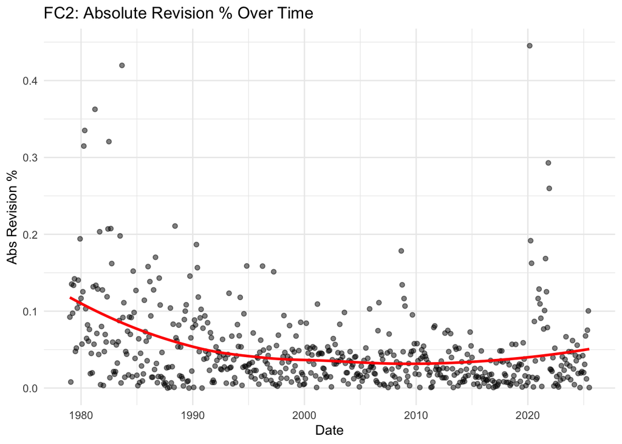

```r
combined_pct |>
  ggplot(aes(x = date, y = abs_rev_pct)) +
  geom_point(alpha = 0.5) +
  geom_smooth(method = "loess", se = FALSE, color = "red") +
  labs(title = "FC2: Absolute Revision % Over Time", x = "Date", y = "Abs Revision %") +
  theme_minimal()
```

```r
cat("FC2 Viz1 - Correlation date vs abs_rev_pct:", round(cor(as.numeric(combined_pct$date), combined_pct$abs_rev_pct), 4), "\n")
```

```
FC2 Viz1 - Correlation date vs abs_rev_pct: -0.271
```

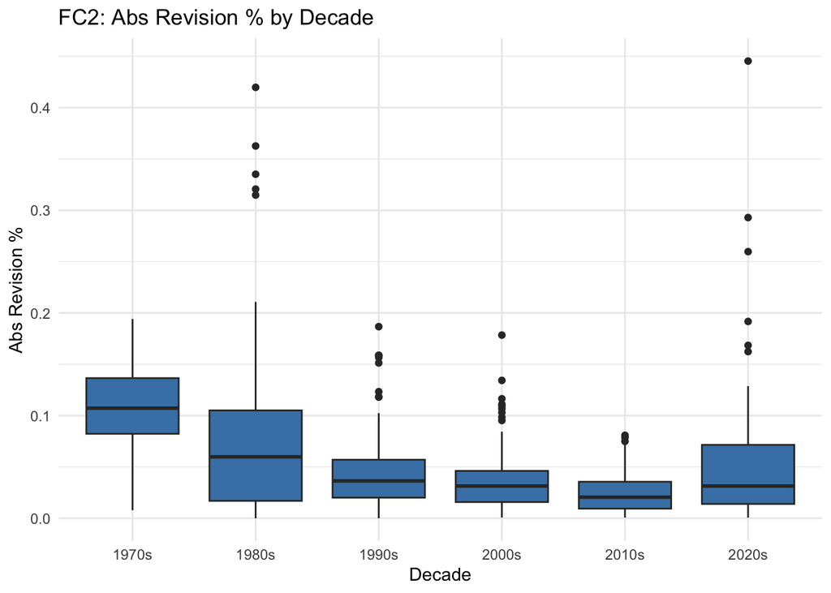

```r
combined_pct |>
  mutate(decade = paste0(floor(year(date) / 10) * 10, "s")) |>
  ggplot(aes(x = decade, y = abs_rev_pct)) +
  geom_boxplot(fill = "steelblue") +
  labs(title = "FC2: Abs Revision % by Decade", x = "Decade", y = "Abs Revision %") +
  theme_minimal()
```

```r
cat("FC2 Viz2 - Boxplot stats:\n")
```

```
FC2 Viz2 - Boxplot stats:
```

```r
combined_pct |>
  mutate(decade = paste0(floor(year(date) / 10) * 10, "s")) |>
  group_by(decade) |>
  summarise(
    median = round(median(abs_rev_pct), 4),
    q25 = round(quantile(abs_rev_pct, 0.25), 4),
    q75 = round(quantile(abs_rev_pct, 0.75), 4)
  )
```

```
# A tibble: 6 × 4
  decade median    q25    q75
  <chr>   <dbl>  <dbl>  <dbl>
1 1970s  0.107  0.0823 0.136
2 1980s  0.0598 0.0169 0.105
3 1990s  0.0364 0.0201 0.057
4 2000s  0.0314 0.0158 0.0461
5 2010s  0.0206 0.0094 0.0355
6 2020s  0.0314 0.0139 0.0715
```

```r
combined_pct |>
  mutate(post2020 = as.character(date >= ymd("2020-01-01"))) |>
  t_test(abs_rev_pct ~ post2020, order = c("TRUE", "FALSE"))
```

```
# A tibble: 1 × 7
  statistic  t_df p_value alternative estimate lower_ci upper_ci
      <dbl> <dbl>   <dbl> <chr>          <dbl>    <dbl>    <dbl>
1      1.10  74.4   0.275 two.sided     0.0105 -0.00852   0.0296
```

**Rating**: PANTS ON FIRE

# Conclusion

Revisions are a normal part of the CES estimation process. Greater revisions for 2020-2021 because of COVID-19 disruption does not prove political manipulation.